Boats Segmentation: Cluster Analysis

**BLOEMEN, GUO, ISLAM, LOPES, PAGSIBIGAN**

## Business Decisions

CreeqBoat needs to expand its business to North America; to support this expansion strategy the Customer Insight department was tasked with conducting market research to gain a better understanding of the North American consumers. In particular, this research will help identify the appropriate customer segments that CreeqBoat should target in order to gain market share and generate increased revenue.

Following the previous factor analysis, the team now proceeds with clustering and segmenting the target clients.

## The Data

Market research was conducted through interviews with 3000 boat owners and intenders. Data was collected on customers attitudes toward boating, their demographics, the types of boats owned, use of boats, price of boats, etc. Segmentation of the customers was based on 29 questions about attitudes, needs and motivations about boating.

Responses for these questions range from 1 to 5, with 1 being strongly disagree and 5 being strongly agree.

## Our Approach

1. Confirm the data in metric
2. Decide whether to scale or standardize the data
3. Decide which variables to use for clustering
4. Define similarity or dissimilarity measures between observations
5. Visualize Individual Attributes and Pair-wise Distances between the Observations
6. Select the clustering method to use and decide how many clusters to have
7. Profile and interpret the clusters
8. Assess the robustness of our clusters

Let's follow these steps.

#### 2. Decide whether to scale or standardize the data

```r
ProjectData_scaled = apply(ProjectData, 2, function(r) {
    if (sd(r) != 0)
        res = (r - mean(r))/sd(r) else res = 0 * r
    res
})
```

While this is typically a necessary step, one has to always do it with care: some times you may want your analytics findings to be driven mainly by a few attributes that take large values; other times having attributes with different scales may imply something about those attributes. In many such cases one may choose to skip step 2 for some of the raw attributes.

We decide to use the unscaled data for now.

#### Step 3. Decide which variables to use for clustering

Below follows the variables (based on factor analysis) the team decided to use to cluster the target clients:

**Well-Informed**: Q1_1_When buying a boat, I do a lot of shopping around and visit multiple dealers

**Brand-conscious**: Q1_4_I only consider buying a boat from a reputable brand

**Practical**: Q1_8_When buying a boat, functionality is more important than style

**Luxurious**: Q1_9_I see my boat as a status symbol

**Techie**: Q1_11_I tend to perform minor boat repairs and maintenance on my own

**Simplistic**: Q1_12_When it comes to boating, I tend to prefer a basic boat with little to no frills

**Adventurous**: Q1_21_Boating helps me escape from everyday life and relax

**Passionate**: Q1_27_Boating is the number one thing I do with my spare time

#### Step 4. Define similarity or dissimilarity measures between observations

In our case we explore two distance metrics: the commonly used **Euclidean distance** as well as a simple one we define manually.

Pairwise Distances between the first 5 observations using The Euclidean Distance Metric

| 1 | 2 | 3 | 4 | 5 |
| --- | --- | --- | --- | --- |
| 0.0 |  |  |  |  |
| 3.2 | 0.0 |  |  |  |
| 3.5 | 2.0 | 0.0 |  |  |
| 3.2 | 2.8 | 3.7 | 0.0 |  |
| 3.6 | 3.0 | 4.4 | 3.3 | 0.0 |

Notice for example that if we use, say, the Manhattan distance metric, these distances change as follows:

Pairwise Distances between the first 5 observations using The Manhattan Distance Metric

| 1 | 2 | 3 | 4 | 5 |
| --- | --- | --- | --- | --- |
| 0.0 |  |  |  |  |
| 8.0 | 0.0 |  |  |  |
| 8.0 | 4.0 | 0.0 |  |  |
| 6.0 | 6.0 | 8.0 | 0.0 |  |
| 7.0 | 7.0 | 11.0 | 9.0 | 0.0 |

Let's now define our own distance metric, as an example. Let's say that the management team of the company believes that two customers are similar if they do not differ in their ratings of the attitudinal questions by more than 2 points. We can manually assign a distance of 1 for every question for which two customers gave an answer that differs by more than 2 points, and 0 otherwise. It is easy to write this distance function in R:

```r
My_Distance_function <- function(x, y) {
    sum(abs(x - y) > 2)
}
```

Here is how the pairwise distances between the respondents now look like.

Pairwise Distances between the first 5 observations using a simple manually defined Distance Metric

| 1 | 2 | 3 | 4 | 5 |
| --- | --- | --- | --- | --- |
| 0.0 |  |  |  |  |
| 0.0 | 0.0 |  |  |  |
| 0.0 | 0.0 | 0.0 |  |  |
| 0.0 | 0.0 | 0.0 | 0.0 |  |
| 1.0 | 0.0 | 1.0 | 0.0 | 0.0 |

In general a lot of creative thinking and exploration should be spent in this step, and as always one may need to come back to this step even after finishing the complete segmentation process - multiple times.

#### Step 5. Visualize Individual Attributes and Pair-wise Distances between the Observations

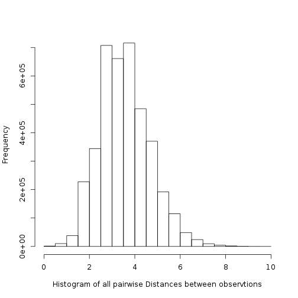

> Visualization is very important for data analytics, as it can provide a first understanding of the data.

#### Step 6. Select the clustering method to use and decide how many clusters to have

With the available data, the team used the Kmean Clustering Method, as the team have defined 5 key segments to target.

The Dendogram below shows 5 major clusters around its branches.

In this note we will use two widely used methods: the **Kmeans Clustering Method**, and the **Hierarchical Clustering Method**. Like all clustering methods, these two also require that we have decided how to measure the distance/similarity between our observations. Explaining how these methods work is beyond our scope. The only difference to highlight is that Kmeans requires the user to define how many segments to create, while Hierarchical Clustering does not.

Let's fist use the **Hierarchial Clustering** method, as we do not know for now how many segments there are in our data. Hierarchical clustering is a method that also helps us visualise how the data may be clustering together. It generates a plot called the **Dendrogram** which is often helpful for visualization - but should be used with care. For example, in this case the dendrogram, using the euclidean distance metric from the earlier steps and the ward hierarchical clustering option (see below as well as help(hclust) in R for more information), is as follows:

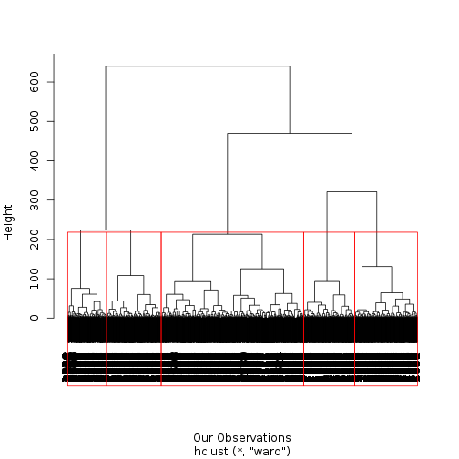

Note that we can draw as many clusters are we choose (e.g. in this case we chose 5 clusters) around the branches of the Dendrogram.

**Using Kmean Clustering**

#### Step 7. Profile and interpret the clusters

The above observations can also be seen when taking the ratio of the averages of the population and each segment:

We can also “visualize” the segments using **snake plots** for each cluster. For example, we can plot the means of the profiling variables for each of our clusters to better visualize differences between segments. For better visualization we plot the standardized profiling variables.

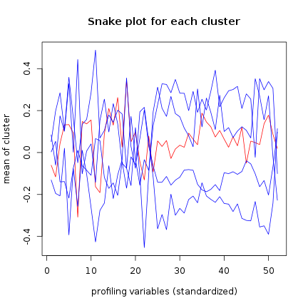

Can we see differences between the segments? Do the segments differ in terms of their average household income and in terms of how often they visit the mall? What else can we say about these segments?

(See interpretation)

We can also compare the averages of the profiling variables of each segment relative to the average of the variables across the whole population. This can also help us better understand whether there are indeed clusters in our data (e.g. if all segments are much like the overall population, there may be no segments). For example, we can measure the ratios of the average for each cluster to the average of the population (e.g. avg(cluster)/avg(population)) and explore a matrix as the following one:

|  | Segment 1 | Segment 2 | Segment 3 | Segment 4 | Segment 5 |
| --- | --- | --- | --- | --- | --- |
| Q2_How many powerboats do you currently own | 0.9479 | 0.8863 | 1.002 | 1.045 | 1.075 |
| Q2_Cluster_Own a boat | 0.9316 | 0.8854 | 1.032 | 1.116 | 0.9643 |
| Q3_How likely would you be to purchase a new boat in the future | 1.007 | 0.965 | 0.9763 | 1.048 | 1.03 |
| Q4_Approximately how much did you pay for your current Boat | 1.078 | 1.012 | 0.9185 | 1.062 | 1.059 |
| Q5_What is the horse power of your engine brand current boat engine the boat you want to buy | 1.063 | 0.813 | 0.8965 | 1.171 | 1.156 |
| Q6_Length of Boat in Feet | 1.043 | 0.9643 | 0.9656 | 1.076 | 1.00 |
| Q7_1_I normally boat alone | 0.8457 | 0.8714 | 1.005 | 0.9753 | 1.222 |
| Q7_2_I boat with my spouse or significant other | 1.041 | 1.003 | 0.9824 | 1.037 | 0.9715 |
| Q7_3_I boat with my family including kids | 1.041 | 0.9697 | 0.9749 | 1.047 | 1.002 |
| Q7_4_I boat with my friends | 1.037 | 0.9373 | 0.9741 | 1.068 | 1.01 |
| Q8_How would you rate your experience regarding boating | 0.9434 | 0.8517 | 1.023 | 1.17 | 0.9504 |
| Q9_1_Fishing Below is a list of activities that may or may not do while boating Please indicate how often you engage in each of these activities | 0.9332 | 0.9039 | 1.02 | 1.024 | 1.053 |
| Q9_2_Swimming Below is a list of activities that may or may not do while boating Please indicate how often you engage in each of these activities | 1.028 | 0.9251 | 0.9631 | 1.033 | 1.079 |
| Q9_3_Cruising Below is a list of activities that may or may not do while boating Please indicate how often you engage in each of these activities | 1.054 | 0.9839 | 0.9558 | 1.046 | 1.025 |
| Q9_4_Water Sports Below is a list of activities that may or may not do while boating Please indicate how often you engage in each of these activities | 1.048 | 0.9193 | 0.947 | 1.053 | 1.086 |
| Q9_5_Entertaining socializing Below is a list of activities that may or may not do while boating Please indicate how often you engage in each of these activities | 1.079 | 0.9679 | 0.9388 | 1.061 | 1.041 |
| Q10_During your boating season how many days out of the year do you typically use your boat | 1.024 | 0.9673 | 0.9583 | 1.175 | 0.9514 |
| Q11_Gender | 1.119 | 1.122 | 0.9415 | 0.9739 | 0.9744 |
| Q12_HOUSEHOLD income | 1.018 | 1.01 | 0.9931 | 1.06 | 0.9453 |
| Q13_Are you now married widowed divorced separated never married or living with a partner | 1.085 | 0.935 | 0.9497 | 0.9727 | 1.103 |
| Q14_Current Employment Status | 0.9635 | 1.164 | 1.057 | 0.8681 | 0.9083 |
| Q15_Age in cluster | 0.9408 | 1.097 | 1.092 | 0.9849 | 0.7953 |
| Q16_Name of the Brand rated | 1.065 | 1.045 | 1.025 | 0.9297 | 0.9165 |
| Q16_1_Is a brand that has been around for a long time | 0.9737 | 0.9667 | 0.982 | 1.036 | 1.055 |
| Q16_2_Has best in class customer service | 1.013 | 0.9117 | 0.9658 | 1.055 | 1.076 |
| Q16_3_Has a strong dealer network | 1.006 | 0.9368 | 0.9698 | 1.07 | 1.045 |
| Q16_4_Is a leader in cutting edge technology | 1.012 | 0.922 | 0.9759 | 1.069 | 1.036 |
| Q16_5_Is a leader in safety | 0.9938 | 0.9568 | 0.9661 | 1.062 | 1.058 |
| Q16_6_Is known for its innovative products | 1.004 | 0.9367 | 0.9721 | 1.074 | 1.039 |
| Q16_7_Is a brand for people who are serious about boating | 1.007 | 0.9451 | 0.9757 | 1.058 | 1.035 |
| Q16_8_Is a good brand for people that are new to boating | 1.005 | 0.9427 | 0.9834 | 1.056 | 1.023 |
| Q16_9_Is a brand I see in the water all the time | 1.019 | 0.9549 | 0.9836 | 1.04 | 1.016 |
| Q16_10_Offers boats that provide a fast and powerful boating experience | 1.014 | 0.9545 | 0.9815 | 1.064 | 1.006 |
| Q16_11_Offers the best boats for socializing | 1.009 | 0.9397 | 0.9619 | 1.048 | 1.076 |
| Q16_12_Offers the best boats for water sports e g tubing ski wakeboard | 1.047 | 0.9638 | 0.9552 | 1.064 | 1.031 |
| Q16_13_Offers boats with superior interior style | 1.034 | 0.9512 | 0.956 | 1.048 | 1.061 |
| Q16_14_Offers boats with superior exterior style | 1.027 | 0.9507 | 0.9613 | 1.065 | 1.042 |
| Q16_15_Offers boats that stand out from the crowd | 1.015 | 0.9518 | 0.969 | 1.08 | 1.022 |
| Q16_16_Offers boats that look cool | 1.026 | 0.9488 | 0.9558 | 1.053 | 1.067 |
| Q16_17_Offers boats that can handle rough weather or choppy water | 1.013 | 0.9499 | 0.9802 | 1.054 | 1.021 |
| Q16_18_Offers boats that can handle frequent and heavy usage | 1.005 | 0.9512 | 0.9801 | 1.058 | 1.024 |
| Q16_19_Offers a wide breadth of product offerings and accessories | 1.015 | 0.9456 | 0.9823 | 1.058 | 1.014 |
| Q16_20_Offers boats that I can move around safely | 1.006 | 0.9562 | 0.9814 | 1.056 | 1.018 |
| Q16_21_Offers boats that are easy to maintain and or repair | 1.023 | 0.9403 | 0.9828 | 1.04 | 1.023 |
| Q16_22_Offers boats that are easy to use | 0.9907 | 0.9407 | 0.9928 | 1.051 | 1.019 |
| Q16_23_Offers boats that are easy to clean up | 1.01 | 0.9427 | 0.9905 | 1.045 | 1.012 |
| Q16_24_Has low prices | 1.013 | 0.9349 | 0.9716 | 0.9934 | 1.099 |
| Q16_25_Is a brand that gives me peace of mind | 1.009 | 0.9149 | 0.9609 | 1.085 | 1.065 |
| Q16_26_Makes me feel I made a smart decision | 1.027 | 0.9323 | 0.9742 | 1.058 | 1.03 |
| Q16_27_Is a brand that impresses others | 1.042 | 0.9088 | 0.9526 | 1.079 | 1.063 |
| Q17_Recommend | 1.122 | 0.6583 | 0.905 | 1.431 | 0.9698 |
| Q18_PurchaseFuture | 1.019 | 1.115 | 1.099 | 0.8983 | 0.7708 |

**INTERPRETATION**

Reviewing, the segments could be defined as follows. Do note that the marital status was not used in this analysis as it did not provide a clear scale in determining its significance in the profiling:

Lastly this segment falls closer to the $74,000 to $84,999 income bracket (Q12).

**PRACTICAL USER** This is a mixed group with more women than men, and brand image is of high importance (Q11). They view boating as social events, and likely to be self-employed or temporarily not working (Q7 & 14).

Lastly this segment falls closer to the $74,000 to $84,999 income bracket (Q12).

**AVERAGE JOE** This is a group composed of mostly men who neither have a distinct fascination nor a stark dislike for boating (Q11). Almost everyone in this group currently own a powerboat however, relative to all other segments, they have the lowest purchase price for their current boats (Q2 & 4). They do not have strong attitudes towards the sport nor do they have a specific use for their boats (Q16).

This segment can be further studied because it currently has no clear preference. Due to their lack of fascination for boating in general, this group will most likely not recommend the purchase of a CreeqBaots product. The objective then is to be able to influence them into recognizing the brand and gearing them away from being passive boaters.

Lastly this segment falls closer to the $60,000 to $74,999 income bracket (Q12).

Lastly this segment falls closer to the $74,000 to $84,999 income bracket (Q12).

**TECHIE NEWBIE** This is a segment that values the power that a boat has and prefers to have at least a mid-range horsepower boat (Q8). Having intermediate experience in boating, they are more knowledgeable about boat specifications (Q5).

Relative to others, this is a fairly young cluster of boaters (Q15). Given this, it is expected for them to use their boat for socializing, however, data suggests the otherwise and shows that they occasionally boat alone. (Q7).

Lastly this segment falls closer to the $50,000 to $59,999 income bracket (Q12).

#### Step 8. Assess the robustness of our clusters

We will skip this step for this exercise. However in practice this is a very important step.

## Interpretation, Decisions and Conclusion

In our view, Creeqboat could use marketing campaigns to target each cluster separately, focusing on the main characteristic to call the attention.

As far as the number of segments, the team concluded that this is the maximum Creeqboat should allocate marketing resources towards. While CreeqBoat should also keep in mind the potential for further segregation the segments when the CreeqBoat brand reach matrurity from a brand awareness perspective.